# 1. Discretized Non-negative Matrix Factorization (`dNMF`)

Koki Tsuyuzaki

Laboratory for Bioinformatics Research, RIKEN Center for Biosystems Dynamics Research  
k.t.the-answer@hotmail.co.jp

2023-03-07

# Introduction

In this vignette, we consider approximating a binary or non-negative matrix as a product of two non-negative low-rank matrices (a.k.a., factor matrices).

Test data is available from `toyModel`.

```r
library("dcTensor")
X <- dcTensor::toyModel("dNMF")
```

You will see that there are five blocks in the data matrix as follows.

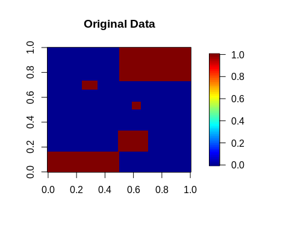

```r
suppressMessages(library("fields"))
image.plot(X, main="Original Data", legend.mar=8)
```

# Binary Matrix Factorization (BMF)

Here, we consider the approximation of a binary data matrix $X$ ($N \times M$) as a matrix product of $U$ ($N \times J$) and $V$ ($M \times J$):

$$X \approx U V' \ \mathrm{s.t.}\ U,V \in \{0,1\}$$

This is known as binary matrix factorization (BMF). Zhang (2007) et al. developed BMF by adding binary regularization term to non-negative matrix factorization (NMF (Lee and Seung 1999; CICHOCK 2009)). For the details of NMF, see also `NMF` function of nnTensor package.

## Basic Usage

In BMF, a rank parameter $J$ ($\leq \min(N, M)$) is needed to be set in advance. Other settings such as the number of iterations (`num.iter`) or factorization algorithm (`algorithm`) are also available. For the details of arguments of dNMF, see `?dNMF`. After the calculation, various objects are returned by `dNMF`.

```r
set.seed(123456)
out_BMF <- dNMF(X, Bin_U=1, Bin_V=1, J=5)
str(out_BMF, 2)
```

```
## List of 6
##  $ U            : num [1:100, 1:5] 0.979 0.979 0.979 0.979 0.979 ...
##  $ V            : num [1:300, 1:5] 0.999 0.999 0.999 0.999 0.999 ...
##  $ RecError     : Named num [1:101] 1.00e-09 1.34e+01 1.34e+01 1.34e+01 1.34e+01 ...
##   ..- attr(*, "names")= chr [1:101] "offset" "1" "2" "3" ...
##  $ TrainRecError: Named num [1:101] 1.00e-09 1.34e+01 1.34e+01 1.34e+01 1.34e+01 ...
##   ..- attr(*, "names")= chr [1:101] "offset" "1" "2" "3" ...
##  $ TestRecError : Named num [1:101] 1e-09 0e+00 0e+00 0e+00 0e+00 0e+00 0e+00 0e+00 0e+00 0e+00 ...
##   ..- attr(*, "names")= chr [1:101] "offset" "1" "2" "3" ...
##  $ RelChange    : Named num [1:101] 1.00e-09 1.19e-04 1.43e-04 1.49e-04 1.48e-04 ...
##   ..- attr(*, "names")= chr [1:101] "offset" "1" "2" "3" ...
```

The reconstruction error (`RecError`) and relative error (`RelChange`, the amount of change from the reconstruction error in the previous step) can be used to diagnose whether the calculation is converged or not.

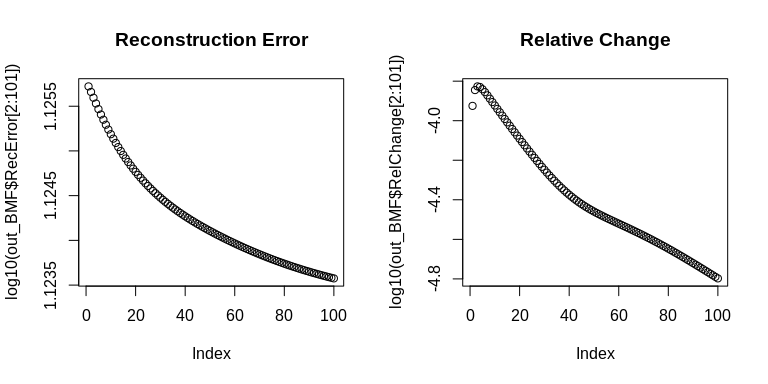

```r
layout(t(1:2))
plot(log10(out_BMF$RecError[2:101]), type="b", main="Reconstruction Error")
plot(log10(out_BMF$RelChange[2:101]), type="b", main="Relative Change")
```

The product of $U$ and $V$ shows whether the original data is well-recovered by `dNMF`.

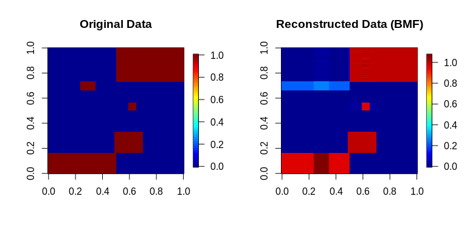

```r
recX <- out_BMF$U %*% t(out_BMF$V)
layout(t(1:2))
image.plot(X, main="Original Data", legend.mar=8)
image.plot(recX, main="Reconstructed Data (BMF)", legend.mar=8)
```

The histograms of $U$ and $V$ show that both $U$ and $V$ take values close to 0 and 1.

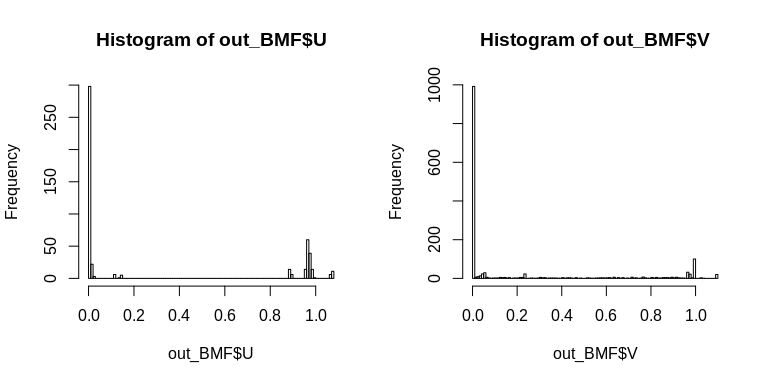

```r
layout(t(1:2))
hist(out_BMF$U, breaks=100)
hist(out_BMF$V, breaks=100)
```

Note that these $U$ and $V$ do not always take the values of 0 and 1 completely. This is because the binarization in BMF is based on the regularization to softly set the values as close to {0,1} as possible, and is not a hard binarization.

```r
head(out_BMF$U)
```

```
##          [,1] [,2] [,3]          [,4] [,5]
## [1,] 0.979044    0    0 3.765852e-104    0
## [2,] 0.979044    0    0 4.277338e-106    0
## [3,] 0.979044    0    0 2.301292e-104    0
## [4,] 0.979044    0    0 1.337948e-104    0
## [5,] 0.979044    0    0 9.347010e-105    0
## [6,] 0.979044    0    0 8.698401e-105    0
```

```r
head(out_BMF$V)
```

```
##           [,1]         [,2] [,3]         [,4]          [,5]
## [1,] 0.9988044 1.072698e-56    0 0.0013906118  0.000000e+00
## [2,] 0.9988248 5.888980e-54    0 0.0003300704 1.735858e-209
## [3,] 0.9988038 4.861490e-57    0 0.0014216661  0.000000e+00
## [4,] 0.9988042 5.637380e-58    0 0.0014015649  0.000000e+00
## [5,] 0.9988029 1.288196e-54    0 0.0014663748  0.000000e+00
## [6,] 0.9988025 6.724228e-58    0 0.0014901051  0.000000e+00
```

If you want to get the {0,1} values, use the `round` function as below:

```r
head(round(out_BMF$U, 0))
```

```
##      [,1] [,2] [,3] [,4] [,5]
## [1,]    1    0    0    0    0
## [2,]    1    0    0    0    0
## [3,]    1    0    0    0    0
## [4,]    1    0    0    0    0
## [5,]    1    0    0    0    0
## [6,]    1    0    0    0    0
```

```r
head(round(out_BMF$V, 0))
```

```
##      [,1] [,2] [,3] [,4] [,5]
## [1,]    1    0    0    0    0
## [2,]    1    0    0    0    0
## [3,]    1    0    0    0    0
## [4,]    1    0    0    0    0
## [5,]    1    0    0    0    0
## [6,]    1    0    0    0    0
```

# Semi-Binary Matrix Factorization (SBMF)

Next, we consider the approximation of a non-negative data matrix $X$ ($N \times M$) as the matrix product of binary matrix $U$ ($N \times J$) and non-negative matrix $V$ ($M \times J$):

$$X \approx U V' \ \mathrm{s.t.}\ U \in \{0,1\}, V \geq 0$$

Here, we define this formalization as semi-binary matrix factorization (SBMF). SBMF can capture discrete patterns from a non-negative matrix.

To demonstrate SBMF, next we use a non-negative matrix from the `nnTensor` package.

```r
suppressMessages(library("nnTensor"))
X2 <- nnTensor::toyModel("NMF")
```

You will see that there are five blocks in the data matrix as follows.

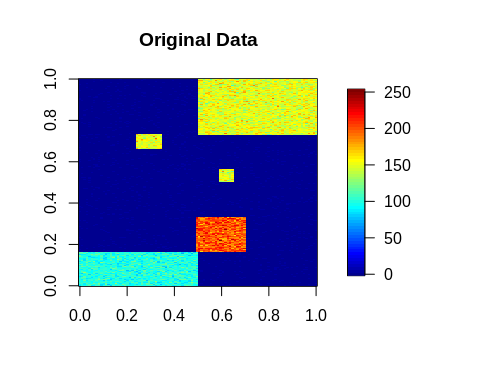

```r
image.plot(X2, main="Original Data", legend.mar=8)
```

## Basic Usage

Switching from BMF to SBMF is quite easy; SBMF is achieved by specifying the binary regularization parameter as a large value like below:

```r
set.seed(123456)
out_SBMF <- dNMF(X2, Bin_U=1E+6, J=5)
str(out_SBMF, 2)
```

```
## List of 6
##  $ U            : num [1:100, 1:5] 0.978 0.984 0.985 0.988 0.977 ...
##  $ V            : num [1:300, 1:5] 98.5 100.7 100 101.5 100.6 ...
##  $ RecError     : Named num [1:101] 1.00e-09 2.99e+03 2.92e+03 2.83e+03 2.77e+03 ...
##   ..- attr(*, "names")= chr [1:101] "offset" "1" "2" "3" ...
##  $ TrainRecError: Named num [1:101] 1.00e-09 2.99e+03 2.92e+03 2.83e+03 2.77e+03 ...
##   ..- attr(*, "names")= chr [1:101] "offset" "1" "2" "3" ...
##  $ TestRecError : Named num [1:101] 1e-09 0e+00 0e+00 0e+00 0e+00 0e+00 0e+00 0e+00 0e+00 0e+00 ...
##   ..- attr(*, "names")= chr [1:101] "offset" "1" "2" "3" ...
##  $ RelChange    : Named num [1:101] 1.00e-09 2.60e-01 2.44e-02 3.18e-02 2.27e-02 ...
##   ..- attr(*, "names")= chr [1:101] "offset" "1" "2" "3" ...
```

`RecError` and `RelChange` can be used to diagnose whether the calculation is converged or not.

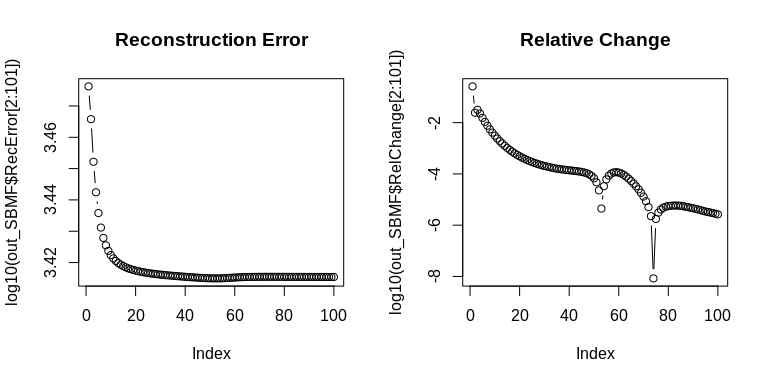

```r
layout(t(1:2))
plot(log10(out_SBMF$RecError[2:101]), type="b", main="Reconstruction Error")
plot(log10(out_SBMF$RelChange[2:101]), type="b", main="Relative Change")
```

The product of $U$ and $V$ shows whether the original data is well-recovered by `dNMF`.

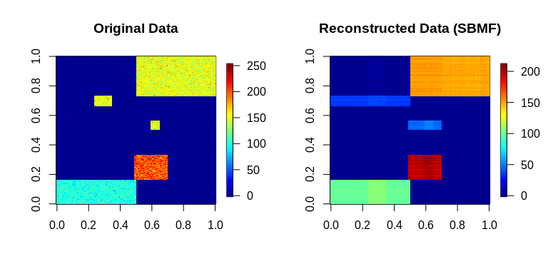

```r
recX2 <- out_SBMF$U %*% t(out_SBMF$V)
layout(t(1:2))
image.plot(X2, main="Original Data", legend.mar=8)
image.plot(recX2, main="Reconstructed Data (SBMF)", legend.mar=8)
```

The histograms of $U$ and $V$ show that $U$ looks binary but $V$ does not.

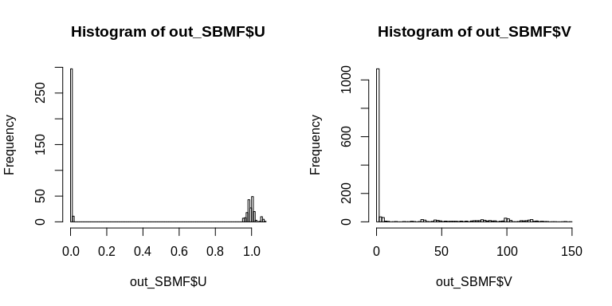

```r
layout(t(1:2))
hist(out_SBMF$U, breaks=100)
hist(out_SBMF$V, breaks=100)
```

# Semi-Ternary Matrix Factorization (STMF)

Finally, we expand the binary regularization to ternary regularization to take {0,1,2} values as below:

$$X \approx U V' \ \mathrm{s.t.}\ U \in \{0,1,2\}, V \geq 0,$$
where $X$ ($N \times M$) is a non-negative data matrix, $U$ ($N \times J$) is a ternary matrix, and $V$ ($M \times J$) is a non-negative matrix.

## Basic Usage

STMF is achieved by specifying the ternary regularization parameter as a large value like the below:

```r
set.seed(123456)
out_STMF <- dNMF(X2, Ter_U=1E+6, J=5)
str(out_STMF, 2)
```

```
## List of 6
##  $ U            : num [1:100, 1:5] 2.02 2.02 2.02 2.02 2.02 ...
##  $ V            : num [1:300, 1:5] 48.7 49.8 49.5 50.2 49.8 ...
##  $ RecError     : Named num [1:101] 1.00e-09 2.52e+03 2.58e+03 2.59e+03 2.58e+03 ...
##   ..- attr(*, "names")= chr [1:101] "offset" "1" "2" "3" ...
##  $ TrainRecError: Named num [1:101] 1.00e-09 2.52e+03 2.58e+03 2.59e+03 2.58e+03 ...
##   ..- attr(*, "names")= chr [1:101] "offset" "1" "2" "3" ...
##  $ TestRecError : Named num [1:101] 1e-09 0e+00 0e+00 0e+00 0e+00 0e+00 0e+00 0e+00 0e+00 0e+00 ...
##   ..- attr(*, "names")= chr [1:101] "offset" "1" "2" "3" ...
##  $ RelChange    : Named num [1:101] 1.00e-09 1.22e-01 2.12e-02 3.09e-03 2.03e-03 ...
##   ..- attr(*, "names")= chr [1:101] "offset" "1" "2" "3" ...
```

`RecError` and `RelChange` can be used to diagnose whether the calculation is converging or not.

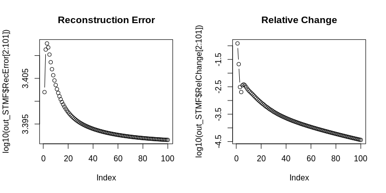

```r
layout(t(1:2))
plot(log10(out_STMF$RecError[2:101]), type="b", main="Reconstruction Error")
plot(log10(out_STMF$RelChange[2:101]), type="b", main="Relative Change")
```

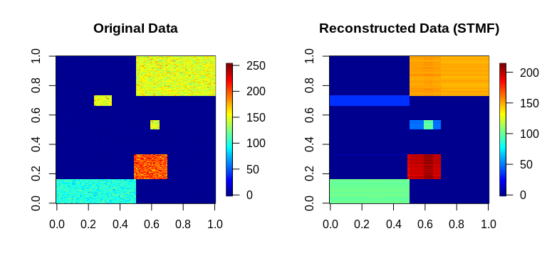

```r
recX <- out_STMF$U %*% t(out_STMF$V)
layout(t(1:2))
image.plot(X2, main="Original Data", legend.mar=8)
image.plot(recX, main="Reconstructed Data (STMF)", legend.mar=8)
```

The histograms of $U$ and $V$ show that $U$ looks ternary but $V$ does not.

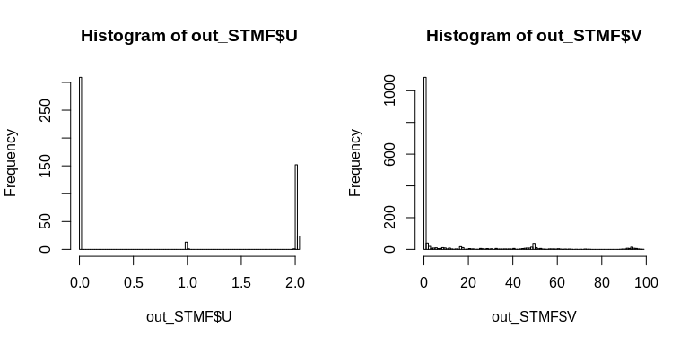

```r
layout(t(1:2))
hist(out_STMF$U, breaks=100)
hist(out_STMF$V, breaks=100)
```

# References

CICHOCK, A. et al. 2009. *Nonnegative Matrix and Tensor Factorizations*. Wiley.

Lee, D., and H. Seung. 1999. “Learning the Parts of Objects by Non-Negative Matrix Factorization.” *Nature* 401: 788–91.

Zhang, Z. et al. 2007. “Binary Matrix Factorization with Applications.” *ICDM 2007*, 391–400.